# Étude analytique de la fréquence des maladies sous surveillance épidémiologique à la Semaine 33 dans la province du Haut-Lomami

ANTOINE UMBA

2025-08-24

# 1 INTRODUCTION

La province du Haut-Lomami est l’une des 26 provinces de la République Démocratique du Congo et aussi issu du démembrement l’ancienne province du Katanga. La division provinciale de la santé du Haut-Lomami existe depuis 2015 en application des reformes dans le domaine sanitaire défini au niveau national. C’est une structure du niveau intermédiaire de la RDC dont le rôle est d’accompagner les zones de santé dans la mise en œuvre des normes et politiques édictés par le niveau central. . La DPS est chargée de la mise en œuvre de la Stratégie de Renforcement du Système de Santé (SRSS) et de l’encadrement des Equipes Cadres de ZS (ECZ) conformément à l’Ordonnance N°82-027 du 19 mars 1982 fixant l’organisation et le cadre organique des Départements du conseil exécutif et du commissariat général au Plan et à l’Arrêté N°CAB/MIN/FP/JMK/PPJ/004/2003 du 20 mars 2003 portant organisation du cadre organique du Ministère de la Santé définissant l’organisation de différents services au niveau de la Division Provinciale de la Santé

## 1.1 Carte Postale de la DPS Haut Lomami

La DPS Haut Lomami a 16 Zones de Santé, sa population totale est de 4.975.254 habitants sur une étendue de 108.204 Km², Sa densité faible de 46 habitants/Km² avec 395 aires de santé (souce:DHIS2)

Elle contient 1 Bureau CD, 6 bureaux et Bureaux des coordinations Provinciales des programmes spécifiques

Sur le plan sanitaire, le paludisme sevit en mode endémique dans toutes les 16 ZS et est la première pathologique mortelle. La fievre typhoide, la pneumonie, les IRA, et les autres pathologies sevissent en mode endémique.

Les maladies comme la rougeole, la poliomyélite, le choléra constituent un groupe des pathologies à potentiel épidémique élevé.

Le Choléra sevit en mode endémo-épidémqiue dans les 8 Zones de Santé qui sont dans l’axe fluvial: BUKAMA, BUTUMBA, KABONDO-DIANDA, KINKONDJA, LWAMBA, MALEMBA, MUKANGA et MULONGO.

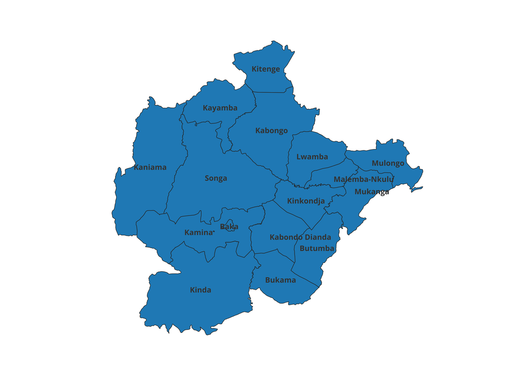

## 1.2 OBJECTIFS

## 1.3 Objectif Général

L’objectif poursuivi dans cette étude est ressortir les tendances, fréquence des maladies sous surveillance épidémiologique dans la province du Haut Lomami

## 1.4 Objectifs Spéciques

Par cette étude, de manière spécifique, nous voulons:

1. Déterminer les pathologies les plus domnantes dans la province
2. évaluer l’évolution de ces malmadies sur 12 semaines
3. ressortir ou dégager les ZS les plus vulnérables
4. Dégager les Zone de Santé silencieuses dans la notification
5. proposer les pistes des solutions

# 2 SOUCE DES DONNEES

Les données qui sont présentées dans ce travail tirent leurs sources de la base IDS produite par l’EPIDATA, tenue par le Bureau Information Sanitaire, Surveillance Épidémiologique, Communication et Recherche de la DPS Haut Lomami. Il s’agit d’une base constituée par la transmission des maladies notifiées hebdomadairement par les 16 Zones de la DPS.

# 3 VARIABLES RETENUES

La base utilisée contient 22 variables au total mais dans ce travail, nous n’utiliserons que 6 variables: la zs (Zone de Santé), la maladie, le total cas, le total déces, la tranche d’âge et le numéro de la semaine épidémiologique (numsem)

# 4 PRESENTATION DES DONNÉES

## 4.1 TAUX DE COMPLÉTUDE DES RAPPORTS

La complétude externe est de 94% avec 15/16 Zones de Santé ayant notifié

La complétude interne des ZS est de 75%

## 4.2 TABLEAU SYNTHESE DE NOTIFICATION A LA SEMAINE 33

| maladie | totalcas | totaldeces |
| --- | --- | --- |
| PALUDISME SUSP | 14221 | 0 |
| IRA | 5341 | 0 |
| PALUDISME CONF | 2790 | 11 |
| PNEUMONIE | 1050 | 0 |
| ROUGEOLE | 675 | 4 |
| FIEVRE TYPHOIDE | 491 | 0 |
| GRIPPE | 430 | 0 |
| DIARRHEE DHY M5 | 414 | 0 |
| MONKEYPOX | 13 | 0 |
| MENINGITE | 7 | 1 |

[output cut: 4 more lines]

## 4.3 PALUDISME SUSPECTS ET CONFIRME

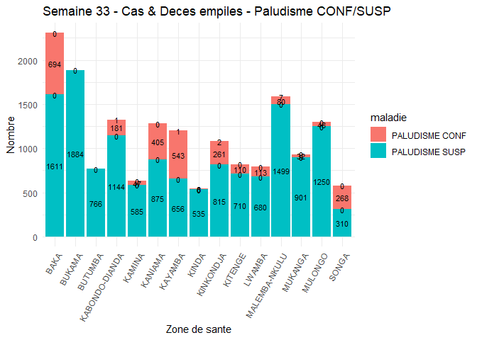

Commentaire: Le graphique ci_dessous montre que c’est la ZS de Bukama et Butumba qui n’ont notifié que des cas de paldisme suspect. Ceci ne s’explique pas magré le contexte des ruptures en TDR paludisme dans un contexte de PCA où les HGR et les CSR peuvent confirmer par GE.

## 4.4 COURBE EVOLUTIVE DU PALUDISME CONF ET SUSPECT (S22-S33)

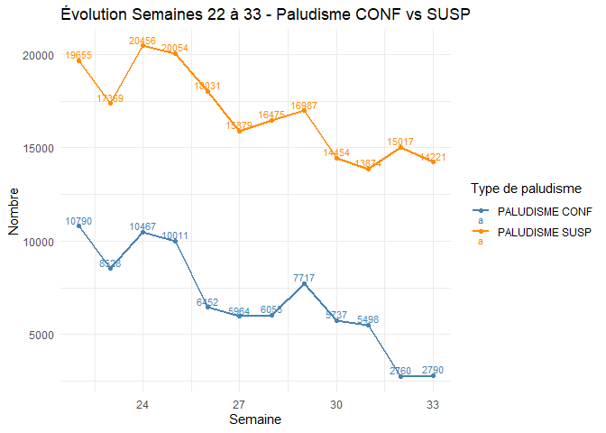

Commmentaires: La courbe ci-dessus montre une régression significative des cas de paludisme confirmés à cause de la rupture en TDR Paludismes dans les ZS.

## 4.5 REPARTITION DES CAS DE PALUDISME CONFIREME SELON LA TRANCHE D’AGE

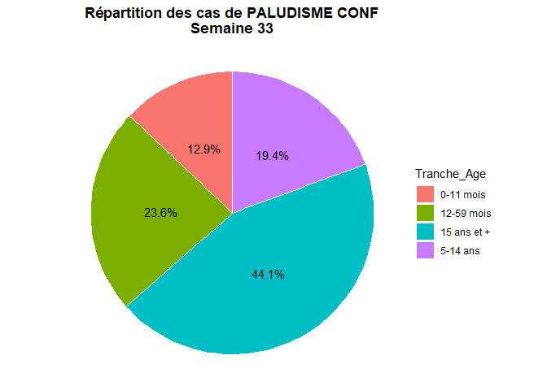

Commentaires: Il ressort du diagramme ci-dessus que c’est la tranche d’âge de 15 et plus qui est la plus touchée avec 44% suivie de celle entre 12-59 mois ans avec 23%

## 4.6 NOTIFICATION DES CAS DE DIARRHÉE AVEC DÉSHYDRATATION M5

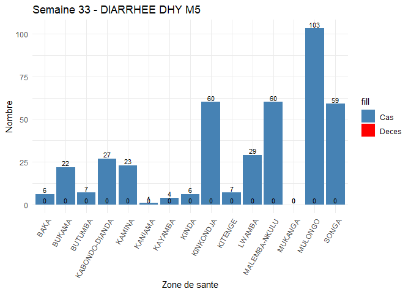

Commentaires: il ressort de ce tableau ci-dessus que c’est la ZS de Mulongo qui a renregistré plus des cas avec 103 cas et 0 décès

## 4.7 COURBE EVOLUTIVE DES CAS DE DIARRHÉE AVEC DÉSHYDRATATION M5 (S22-S33)

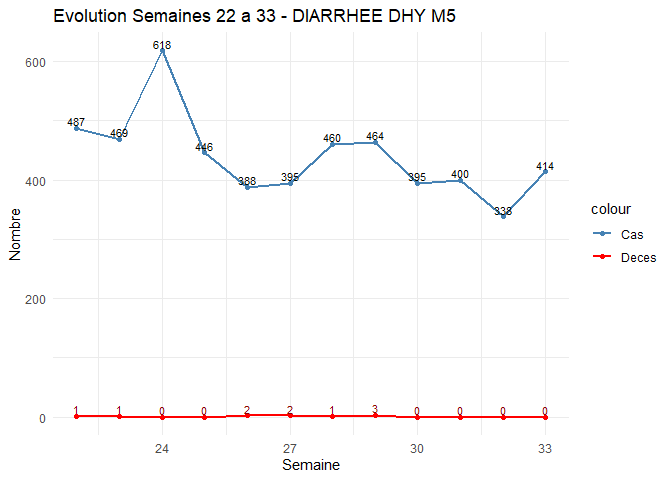

Comentaires: On note par cette courbe une ascension entre la semaine 32 et 33 avec un pic à la S24

## 4.8 C. NOTIFICATOION DES CAS DE DIARRHÉE SANGLANTE

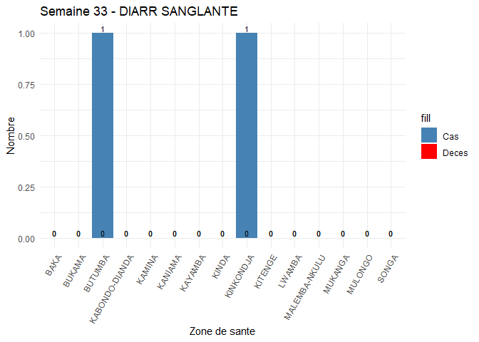

Commentaires: On notre 1 cas et 0 décès par Zone de santé de Butumba et Kinkondja

## 4.9 COURBE EVOLUTIVE DES CAS DE DIARRHÉE SANGLANTE (S22-S33)

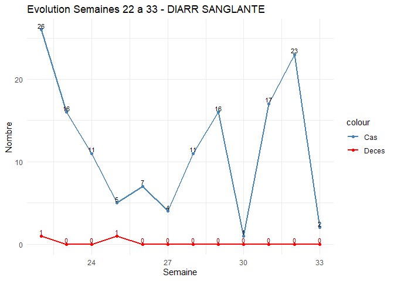

Commentaires: la courbe ci-dessus montre une chutte libre des cas entre la S32 et la S33 passant de 23 à 2

## 4.10 NOTIFICATOION DES CAS DE FIEVRE TYPHOIDE

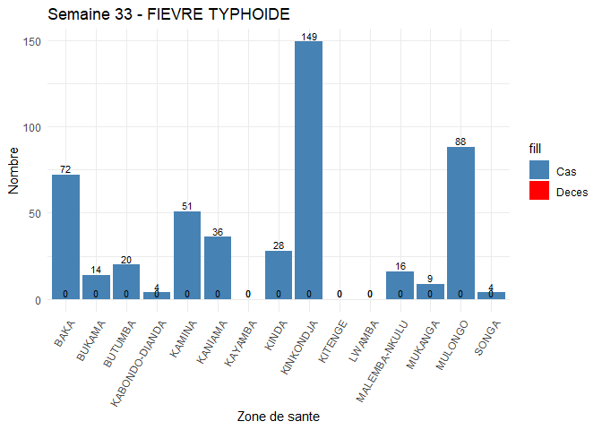

Commentaires: La Ft sevit en mode endémique dans la province, on note que c’est la ZS de Kinkondja quia plus notifié avec 149 cas et 0 décès

## 4.11 COURBE EVOLUTIVE DES CAS DE FIEVRE TYPHOIDE (S22-S3)

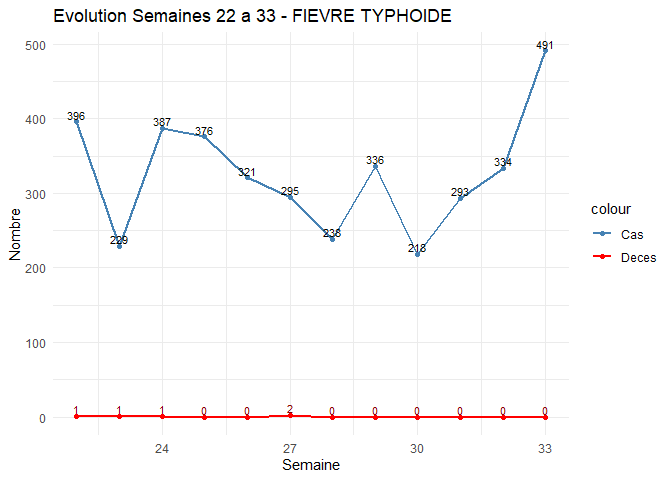

Commentaires: on note une ascension depuis la S30 à la S33

## 4.12 NOTIFICATOION DES CAS DE CHOLERA

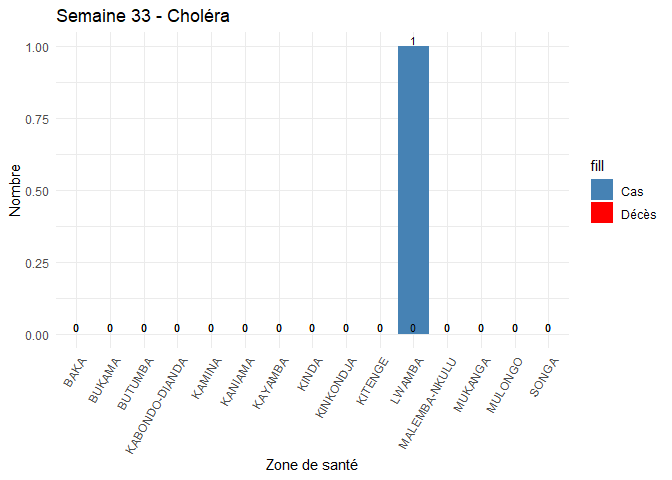

Commentaires: Comme dit ci-haut, le choléra sevit en mode endémo-epidémique dans 8 ZS de la Province, malgré la pleine saison sèche, Lwamba a notifié un cas et 0 décès.

## 4.13 COURBE EVOLUTIVE DES CAS DE CHOLERA (S22-S33)

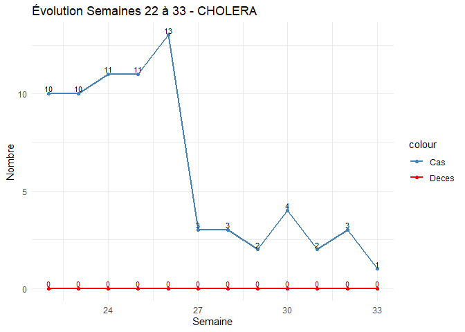

Commentaires: on note une évolution régressive entre la S32 et la S33

## 4.14 NOTIFICATION DES CAS DE MENINGITE

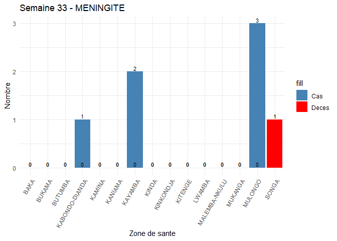

Commentaire: La Zone de Mulongo, notifie souvent plus de cas de méningite sans prélèvement, elle a plus de cas avec 3 et 0 décès

## 4.15 COURBE EVOLUTIVE DES CAS DE MENINGITE (S22-S33)

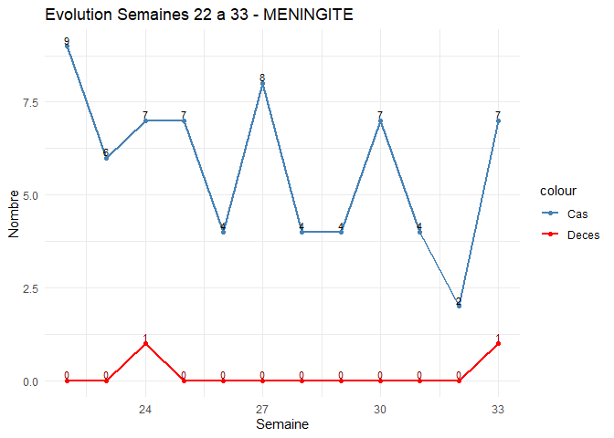

Commentaires: on note une ascension entre la S32 et la S33

## 4.16 NOTIFICATION DES CAS DE PFA

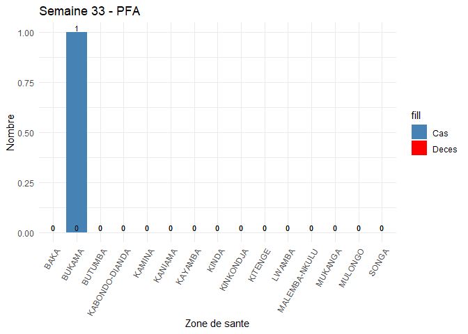

Commentaires: Un seul cas de PFA a été notifié par la ZS de Bukama

## 4.17 COURBE EVOLUTIVE DES CAS DE PFA (S22-S33)

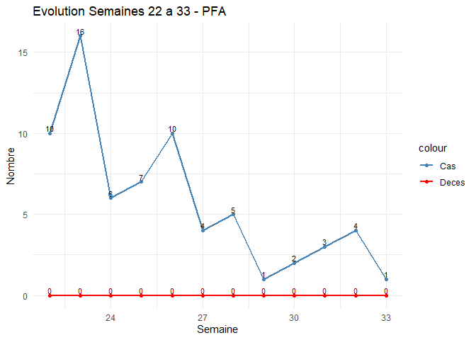

Commentaires: Une évolution régressive est notée entre la S32 et la S33

## 4.18 NOTIFICATION DES CAS DES IRA

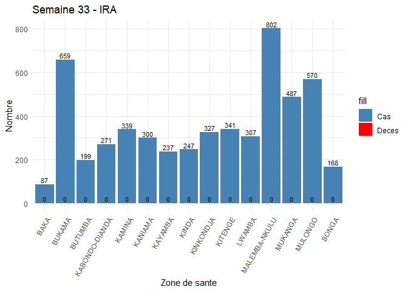

Commentaires: C’est la ZS de Malemba-Nkulu qui aa plus notifié avec 802 et 0 décès

## 4.19 COURBE EVOLUTIVE DES CAS DES IRA (S22-S33)

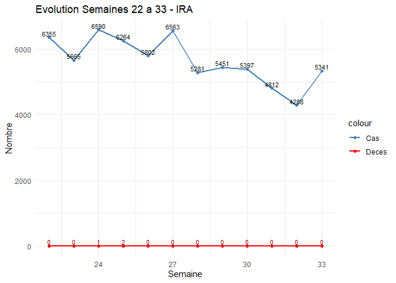

Commentaires: une ascension est notée entre la S32 et la S33

## 4.20 NOTIFICATION DES CAS DE LA ROUGEOLE

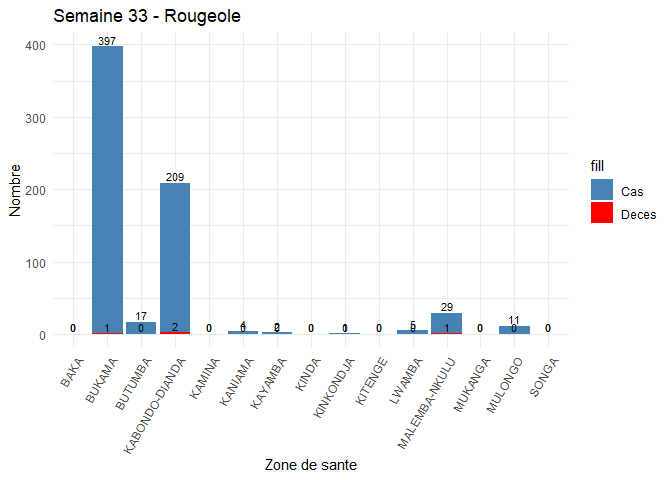

## 4.21 COURBE EVOLUTIVE DES CAS DE ROUGEOLE (S22-S33)

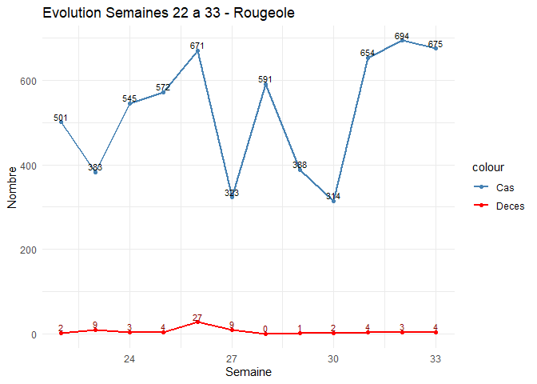

Commentaires: on note une évolution ascendante puis régressive entre la S32 et la S33

## 4.22 REPARTITION DES CAS DE LA ROUGEOLE SUR CARTE

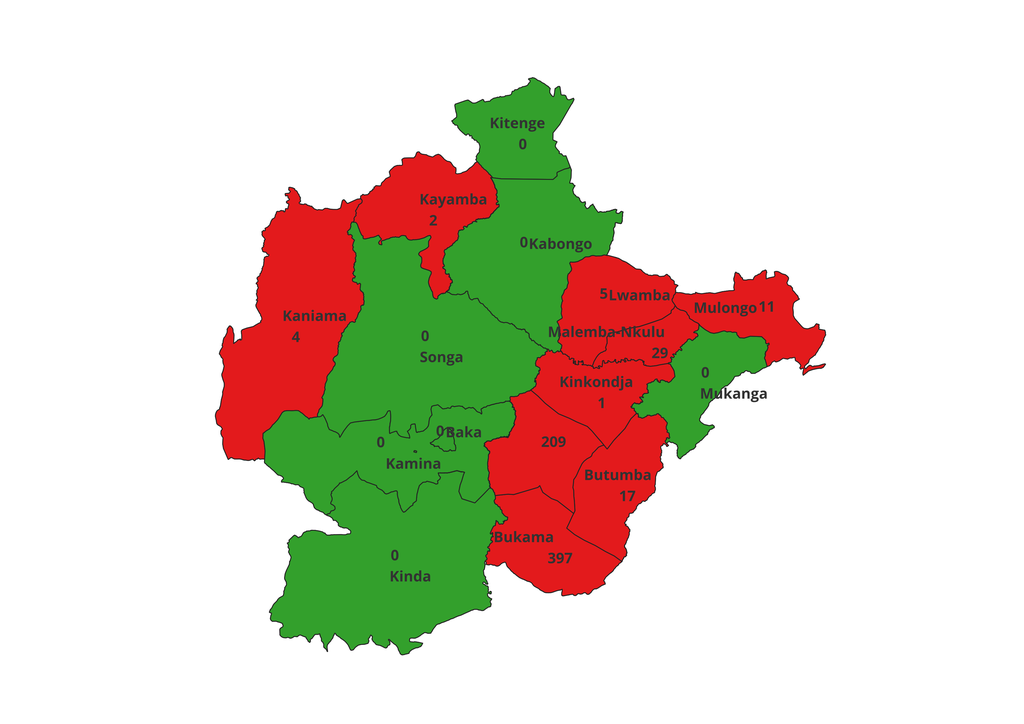

## 4.23 NOTIFICATION DES CAS DE MPOX

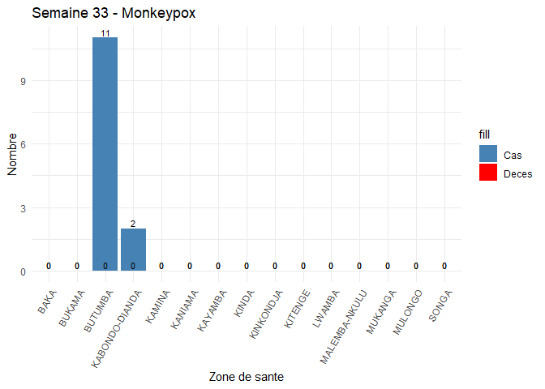

Commentaires: Depuis quelques semaines, c’est la ZS de Butumba qui notifie plus des cas avec 11 cas et 0 décès à la S33

## 4.24 COURBE EVOLUTIVE DES CAS DE MPOX (S22-S33)

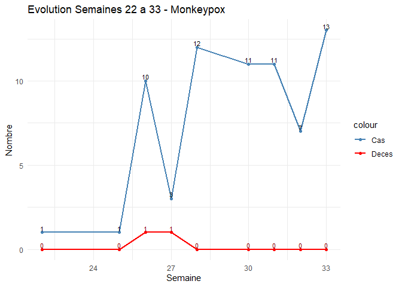

## 4.25 NOTIFICATION DE CAS DE PNEUMONIE

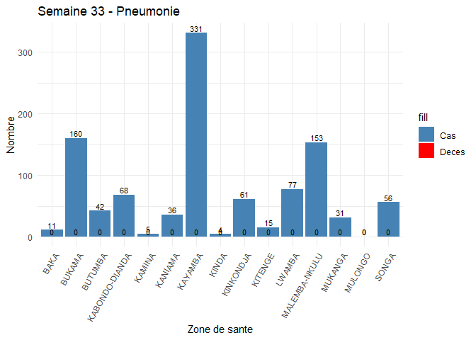

Commentaires: Il se dégage de ce graphique que c’est la ZS de KAYAMBA qui plus notifié avec 331 cas et 0 dècès.

## 4.26 COURBE EVOLUTIVE DES CAS DE PNEUMONIE (S22-S33)

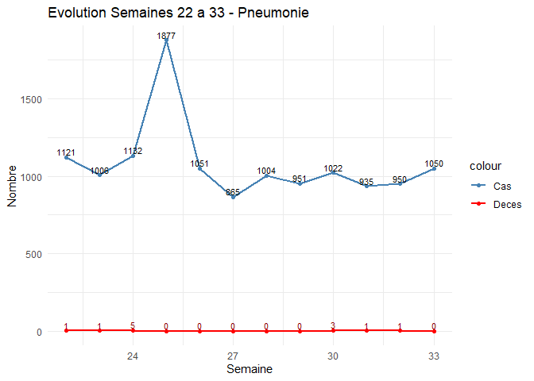

## 4.27 NOTIFICATION DES CAS DE DECES MATERNELS

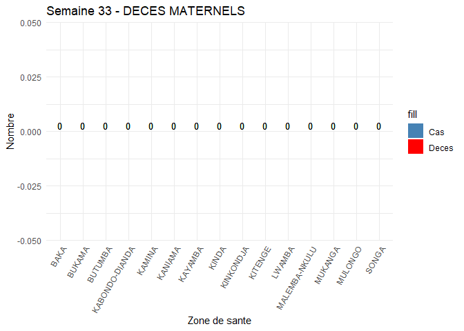

Commentaires: Aucun décès maternel n’a été notifié à la S33

## 4.28 COURBE EVOLUTIVE DES DECES MATERNELS (S22-S33)

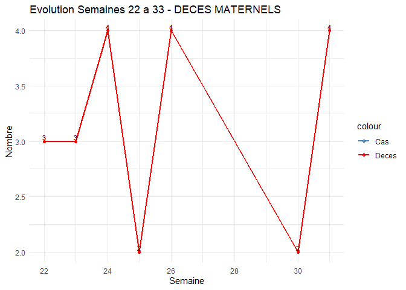

## 4.29 NOTIFICATION DES CAS DE FIEVRE JAUNE

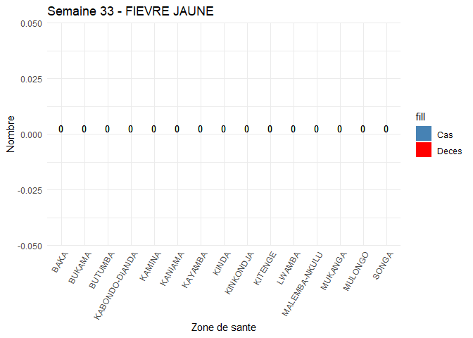

Commentaires: aucun cas de Fièvre Jaune n’a été notifié à la S33

## 4.30 COURBE EVOLUTIVE DES CAS DE FIEVRE JAUNE (S22-33)

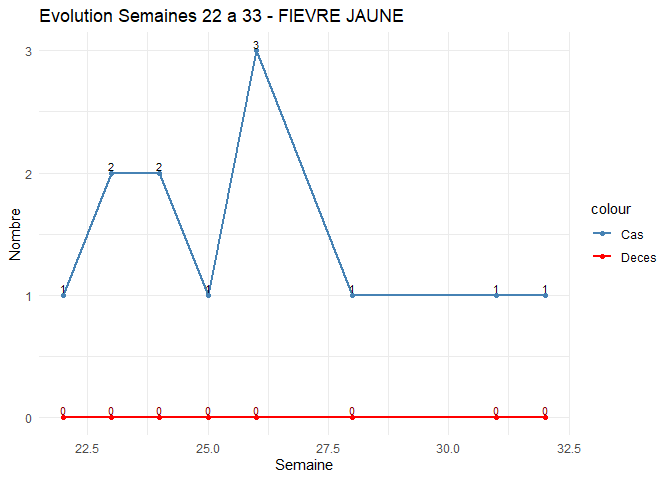

Commentaires: on note que pendant deux semaines consécutives soit S31 et S32, il y a eu notification des cas mais pas à la S33.

## 4.31 NOTIFICATION DES CAS DE TNN

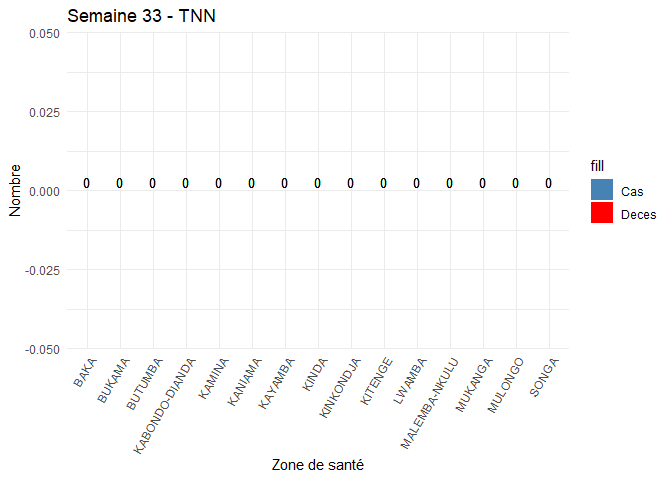

Commentaires: aucun cas n’a été notfié à la S33

## 4.32 COURBE EVOLUTIVE DES CAS DE TNN (S22-33)

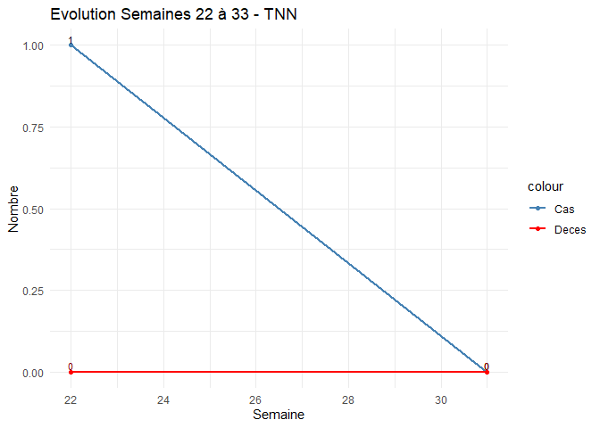

Commentaires: depuis la S23 à la S33, on note une accalmie

# 5 CONCLUSION

# 6 RECOMMANDATIONS

Après discussion dans la réunion de la surveillance épimiolgique, ces recommandations ont été retenues:

1. Demander des explications aux ZS qui notifient 0 cas de paludisme confirmé alors que les HGR, CSR peuvent confirmer par la GE;
2. Rappeler aux ZS de Kabondo et Butumba, d’assurer le suivi des contacts des cas suspects de Mpox
3. Mener un plaidoyer pour l’acquisition des kits de prélèvements Mpox et de TDR paludisme